# Auswertung Temperatur- und Feuchtigkeits-Daten 18.11.2025-09.12.2025

Robin Gummels, Humam Hikmat, Lenn Kruck

# Wir haben unsere Auswertung mit R gemacht

## Was ist R?

- Open-Source Programmiersprache speziell für Statistik und Datenanalyse
- Bringt tausende Pakete für Auswertung, Visualisierung und Reproduzierbarkeit mit
- Funktioniert interaktiv (Konsole/RStudio) und in Skripten für reproduzierbare Workflows
- Läuft auf allen gängigen Betriebssystemen und ist frei verfügbar

## Warum R?

- Saubere Trennung von Code, Daten und Ergebnis: Analysen bleiben nachvollziehbar
- Starke Visualisierung (z.B. `ggplot2`) für schnelle Diagramme unserer Messdaten
- Große Community und Dokumentation; Probleme sind meist schon gelöst
- Passt gut zu Quarto: Text, Code und Grafiken in einer präsentation kombinierbar

## Daten einlesen - Steinfurter Straße

Als erstes Laden wir die Daten von der Steinfurter Straße:

```r
# Header aus erster Zeile auslesen
csv_headers = read.csv2(file = "data/data-as-csv/metMastSteinfurterStr.csv",
                        header = FALSE, nrows = 1, as.is = TRUE)

# Daten ab Zeile 6 einlesen mit den Header-Namen
data <- read.csv2(
  "data/data-as-csv/metMastSteinfurterStr.csv",
  skip = 5,
  header = FALSE,
  dec = ","
)
colnames(data) <- csv_headers

# Index für Plots erstellen
data$index <- 1:nrow(data)
```

|  | Zeitstempel | ID | Gesamtniederschlag [mm] | Durschnittl. Lufttemperatur [°C] | Max. Lufttemperatur [°C] | Min. Lufttemperatur [°C] | Durschnittl. rel. Luftfeuchtigkeit [%] | Max. rel. Luftfeuchtigkeit [%] | Min. rel. Luftfeuchtigkeit [%] | Durchschn. Luftdruck [hPa] | Einfallende kurzwellige Strahlung [W/m2] | Reflektierte kurzwellige Strahlung [W/m2] | Einfallende langwellige Strahlung [W/m2] | Ausgehende langwellige Strahlung [W/m2] | Durchschnittl. Temperatur vom Strahlungssensor [°C] | Windgeschwindigkeit Ultraschallanemometer [m/s] | Windrichtung Ultraschallanemometer [°] | Standardabweichung Windrichtung Ultraschallanemometer [°] | Windgeschwindigkeit Propelleranemometer [m/s] | Windrichtung Propelleranemometer [°] | Standardabweichung Windrichtung Propelleranemometer [°] | Niedrigste Batteriespannung [Volt] | Min. Temperatur Logger Außenhülle [°C] | Max. Temperatur Logger Außenhülle [°C] | index |
| --- | --- | --- | --- | --- | --- | --- | --- | --- | --- | --- | --- | --- | --- | --- | --- | --- | --- | --- | --- | --- | --- | --- | --- | --- | --- |
| 1 | 18.11.2025 12:40 | 14 | 0 | 4.155 | 4.193 | 4.118 | 98.3 | 98.5 | 98.2 | 1001.511 | 53.63 | 11.43 | 323.3 | 338.3 | 4.265 | 4.164 | 196.78 | 10.08 | 3.901 | 196.38 | 11.99 | 12.96 | 4.647 | 4.673 | 1 |
| 2 | 18.11.2025 12:50 | 15 | 0 | 4.225 | 4.28 | 4.132 | 98.1 | 98.2 | 98 | 1009.519 | 48.98 | 9.43 | 324.7 | 339.8 | 4.227 | 3.471 | 200.39 | 11.88 | 3.225 | 201.08 | 12.67 | 12.73 | 4.596 | 4.646 | 2 |
| 3 | 18.11.2025 13:00 | 16 | 0.4 | 4.239 | 4.298 | 4.163 | 98.1 | 98.3 | 98 | 1009.457 | 57.05 | 10.65 | 325.1 | 339.9 | 4.161 | 3.12 | 197.07 | 13.01 | 2.911 | 197.58 | 14.65 | 12.54 | 4.592 | 4.665 | 3 |
| 4 | 18.11.2025 13:10 | 17 | 0.1 | 4.27 | 4.337 | 4.226 | 98.2 | 98.4 | 98 | 1009.286 | 75.02 | 14.18 | 325.2 | 339.9 | 4.14 | 3.286 | 190.63 | 12.69 | 3.047 | 190.78 | 14.02 | 12.57 | 4.665 | 4.795 | 4 |
| 5 | 18.11.2025 13:20 | 18 | 0 | 4.329 | 4.456 | 4.23 | 97.4 | 98 | 96.9 | 1009.13 | 124.5 | 26.95 | 319.9 | 340.2 | 4.22 | 4.107 | 195.53 | 12.28 | 3.913 | 195.48 | 14.15 | 12.67 | 4.784 | 4.917 | 5 |
| 6 | 18.11.2025 13:30 | 19 | 0 | 4.466 | 4.544 | 4.312 | 96.8 | 97.1 | 96.5 | 1008.998 | 120.4 | 24.79 | 317.5 | 341.8 | 4.399 | 3.425 | 192.05 | 14.65 | 3.181 | 192.08 | 15.71 | 14.24 | 4.918 | 5.026 | 6 |
| 7 | 18.11.2025 13:40 | 20 | 0 | 4.502 | 4.572 | 4.431 | 96.4 | 96.7 | 95.9 | 1008.808 | 98.9 | 18.99 | 317.5 | 341.5 | 4.449 | 3.484 | 194.77 | 13.94 | 3.278 | 195.18 | 15.29 | 14.23 | 5.027 | 5.103 | 7 |
| 8 | 18.11.2025 13:50 | 21 | 0 | 4.464 | 4.522 | 4.375 | 95.3 | 96 | 94.9 | 1008.734 | 82.7 | 15.64 | 319.6 | 342.7 | 4.393 | 4.111 | 200.01 | 12.19 | 3.974 | 200.08 | 13.42 | 14.22 | 5.038 | 5.1 | 8 |
| 9 | 18.11.2025 14:00 | 22 | 0 | 4.494 | 4.585 | 4.396 | 95.3 | 95.9 | 94.8 | 1008.566 | 87.3 | 18.29 | 319.5 | 341.6 | 4.385 | 3.213 | 190 | 16.33 | 2.95 | 190.78 | 16.49 | 14.23 | 5.074 | 5.305 | 9 |
| 10 | 18.11.2025 14:10 | 23 | 0 | 4.485 | 4.551 | 4.381 | 95.5 | 96 | 95.2 | 1008.55 | 74.73 | 17.29 | 321.5 | 339.4 | 4.416 | 3.408 | 187.4 | 13.62 | 3.208 | 188.08 | 14.32 | 14.24 | 5.306 | 5.412 | 10 |

[output cut: 190 more lines]

## Lufttemperatur - Zeitreihe

```
   Min. 1st Qu.  Median    Mean 3rd Qu.    Max.
 -1.981   3.286   5.269   5.372   7.480  13.680
```

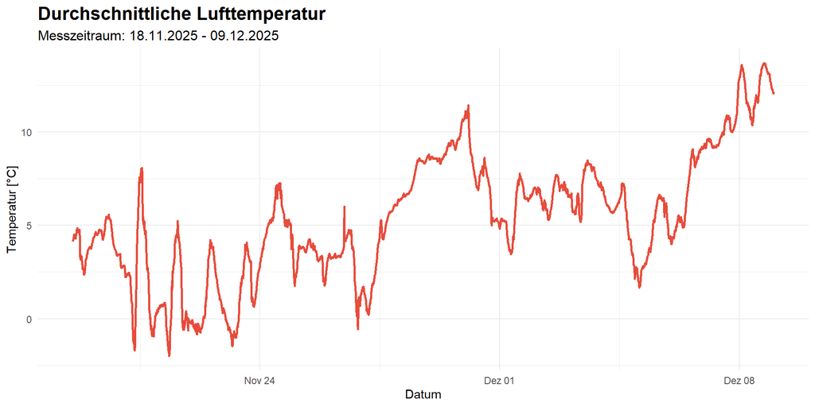

## Tagesgang: Daily Min/Mean/Max + Amplitude

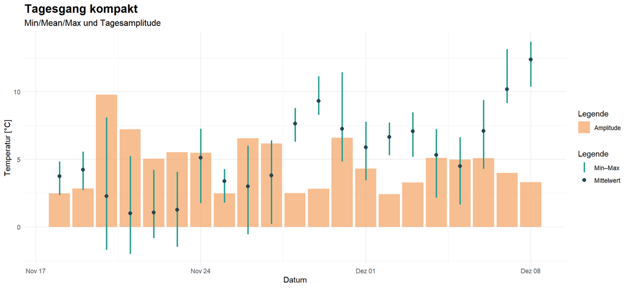

## Luftfeuchtigkeit - Zeitreihe

```
   Min. 1st Qu.  Median    Mean 3rd Qu.    Max.
  32.59   87.40   95.70   89.78   99.90  100.00
```

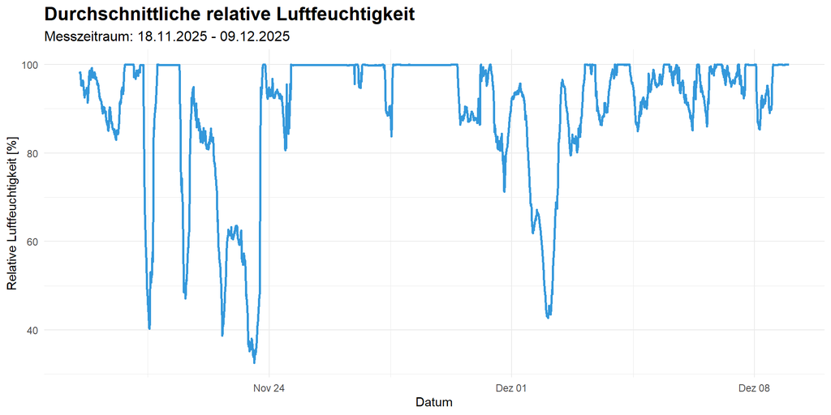

## Lufttemperatur und Luftfeuchtigkeit

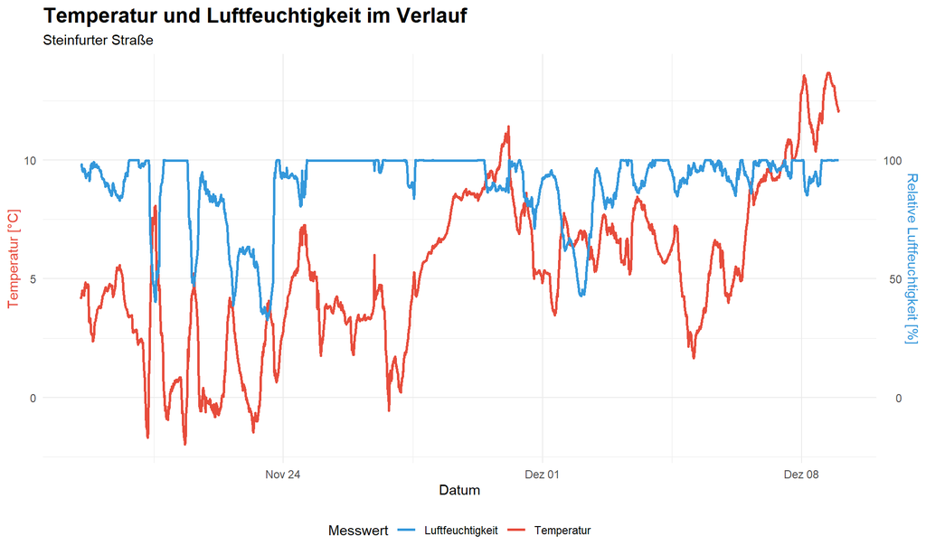

## Temperatur- und Feuchteänderung: Stündlich aggregiert

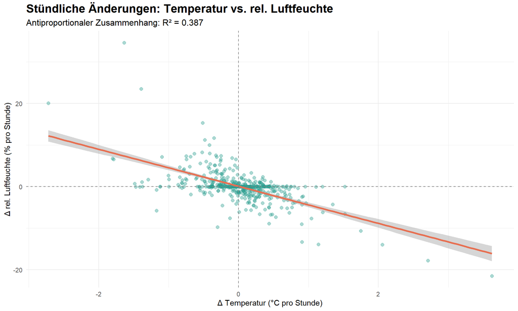

## Stündliche Änderungen: Ohne Nullwerte (ΔRH = 0)

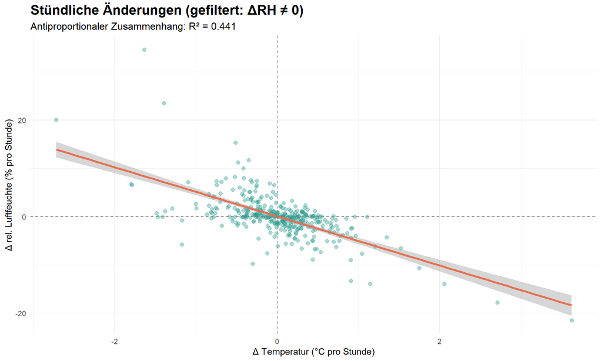

## Vergleich - Temperatur

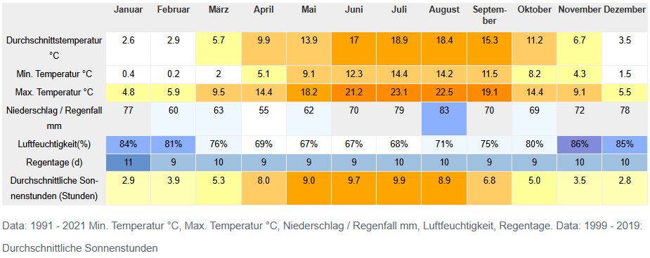

Klimatabelle Münster

```
November 2025:
```

```
   Min. 1st Qu.  Median    Mean 3rd Qu.    Max.
 -1.981   2.000   3.849   4.099   6.095  11.430
```

```
Dezember 2025:
```

```
   Min. 1st Qu.  Median    Mean 3rd Qu.    Max.
  1.666   5.626   6.816   7.355   9.180  13.680
```

## Vergleich - Luftfeuchtigkeit

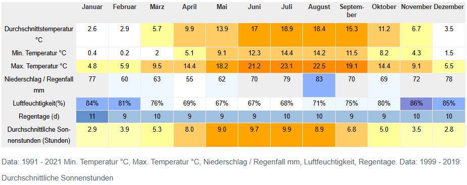

Klimatabelle Münster

```
November 2025:
```

```
   Min. 1st Qu.  Median    Mean 3rd Qu.    Max.
  32.59   85.90   97.20   89.11   99.90  100.00
```

```
Dezember 2025:
```

```
   Min. 1st Qu.  Median    Mean 3rd Qu.    Max.
  42.73   89.10   95.00   90.83   99.30  100.00
```

## Was ist die absolute Luftfeuchtigkeit?

Die **absolute Luftfeuchtigkeit** gibt an, wie viel Wasserdampf tatsächlich in der Luft enthalten ist.

- **Definition:** Masse des Wasserdampfs pro Volumeneinheit Luft (in g·m⁻³ oder kg·m⁻³)
- **Unabhängig von der Temperatur:** Der Wert ändert sich nur, wenn Wasser verdunstet oder kondensiert
- **Unterschied zur relativen Feuchte:** Die relative Feuchte (%) zeigt, wie “voll” die Luft ist – die absolute zeigt die tatsächliche Wassermenge

## Absolute Feuchte - Theorie

**Formel:**
$$a = \frac{e \cdot 100}{R_w \cdot T}$$

| Symbol | Bedeutung | Einheit |
| --- | --- | --- |
| $a$ | Absolute Feuchte | kg·m⁻³ |
| $e$ | Dampfdruck | hPa |
| $R_w$ | Gaskonstante H₂O | 461,5 J/(kg·K) |
| $T$ | Lufttemperatur | K |

**Dampfdruck aus rel. Feuchte:**
$$e = \frac{RH}{100} \cdot e_s$$

**Sättigungsdampfdruck (Magnus):**
$$e_s = 6{,}112 \cdot e^{\frac{17{,}67 \cdot T_C}{T_C + 243{,}5}}$$

## Absolute Feuchte - Berechnung

```r
# Spezifische Gaskonstante für Wasserdampf [J/(kg·K)]
Rw <- 461.5

# Temperatur und rel. Feuchte aus den korrekten Spalten
temperatur <- data$`Durschnittl. Lufttemperatur [°C]`
rel_feuchte <- data$`Durschnittl. rel. Luftfeuchtigkeit [%]`

# Temperatur in Kelvin umrechnen
T_kelvin <- temperatur + 273.15

# Sättigungsdampfdruck nach Magnus-Formel [hPa]
es <- 6.112 * exp((17.67 * temperatur) / (temperatur + 243.5))

# Aktueller Dampfdruck [hPa]
e <- (rel_feuchte / 100) * es

# Absolute Feuchte [kg·m⁻³]
# Formel: a = (e * 100) / (Rw * T)
# Faktor 100: Umrechnung hPa -> Pa
data$absolute_feuchte <- (e * 100) / (Rw * T_kelvin)

# Zeitstempel konvertieren
data$Zeit <- as.POSIXct(data$Zeitstempel, format = "%d.%m.%Y %H:%M")
```

```r
summary(data$absolute_feuchte)
```

```
    Min.  1st Qu.   Median     Mean  3rd Qu.     Max.
0.001893 0.005390 0.006283 0.006419 0.007496 0.011819
```

## Absolute Feuchte - Zeitreihe

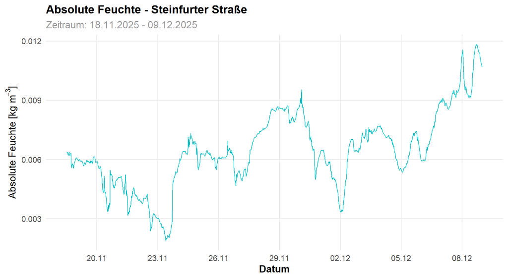

```r
library(ggplot2)

ggplot(data, aes(x = Zeit, y = absolute_feuchte)) +
  geom_line(color = "#00BFC4", linewidth = 0.5) +
  labs(
    title = "Absolute Feuchte - Steinfurter Straße",
    subtitle = "Zeitraum: 18.11.2025 - 09.12.2025",
    x = "Datum",
    y = expression("Absolute Feuchte [kg m"^{-3}*"]"),
  ) +
  theme_minimal(base_size = 14) +
  theme(
    plot.title = element_text(face = "bold", size = 16),
    plot.subtitle = element_text(color = "gray60"),
    axis.title = element_text(face = "bold"),
    panel.grid.minor = element_blank()
  ) +
  scale_x_datetime(date_labels = "%d.%m", date_breaks = "3 days")
```

[figure not shown]

## Absolute vs. Relative Luftfeuchtigkeit

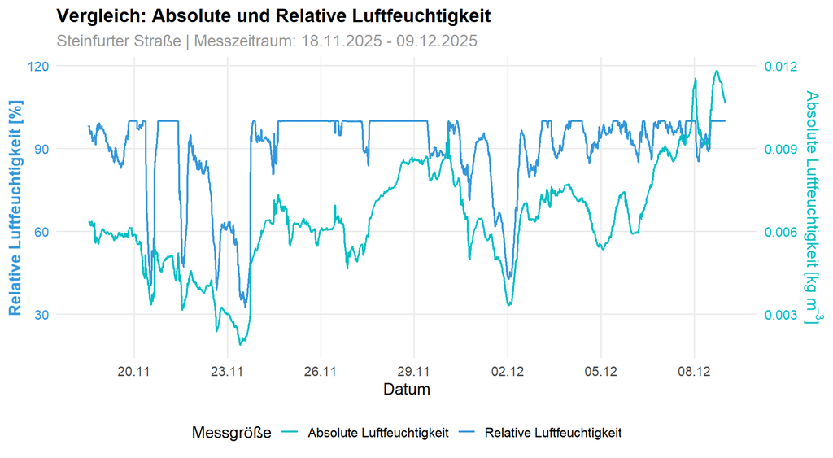

```r
library(ggplot2)

ggplot(data, aes(x = Zeit)) +
  geom_line(aes(y = `Durschnittl. rel. Luftfeuchtigkeit [%]`,
                color = "Relative Luftfeuchtigkeit"), linewidth = 0.8) +
  geom_line(aes(y = absolute_feuchte * 10000,
                color = "Absolute Luftfeuchtigkeit"), linewidth = 0.8) +
  scale_y_continuous(
    name = "Relative Luftfeuchtigkeit [%]",
    sec.axis = sec_axis(~./10000, name = expression("Absolute Luftfeuchtigkeit [kg m"^{-3}*"]"))
  ) +
  scale_color_manual(values = c("Relative Luftfeuchtigkeit" = "#3498DB",
                                "Absolute Luftfeuchtigkeit" = "#00BFC4")) +
  labs(title = "Vergleich: Absolute und Relative Luftfeuchtigkeit",
       subtitle = "Steinfurter Straße | Messzeitraum: 18.11.2025 - 09.12.2025",
       x = "Datum",
       color = "Messgröße") +
  theme_minimal(base_size = 14) +
  theme(
    legend.position = "bottom",
    plot.title = element_text(face = "bold", size = 16),
    plot.subtitle = element_text(color = "gray60"),
    axis.title.y.left = element_text(color = "#3498DB", face = "bold"),
    axis.title.y.right = element_text(color = "#00BFC4", face = "bold"),
    axis.text.y.left = element_text(color = "#3498DB"),
    axis.text.y.right = element_text(color = "#00BFC4"),
    panel.grid.minor = element_blank()
  ) +
  scale_x_datetime(date_labels = "%d.%m", date_breaks = "3 days")
```

[figure not shown]

## Zusammenfassung: Absolute vs. Relative Luftfeuchtigkeit

### Warum verhalten sich beide unterschiedlich?

- Die **relative Feuchte** hängt von der Sättigungskapazität der Luft ab → steigt die Temperatur, sinkt die relative Feuchte (bei gleichem Wassergehalt)
- Die **absolute Feuchte** zeigt den tatsächlichen Wasserdampfgehalt → ändert sich nur bei Verdunstung, Kondensation oder Luftmassenwechsel

## Erkenntnisse aus den Messdaten

**Beobachtungen:**

- Tagsüber (wärmer): Relative Feuchte sinkt, absolute bleibt stabil
- Nachts (kälter): Relative Feuchte steigt oft auf ~100% (Taupunkt erreicht)
- Absolute Feuchte zeigt Änderungen bei Wetterwechsel (neue Luftmassen)

**Interpretation:**

- Hohe relative Feuchte bedeutet **nicht** automatisch viel Wasser in der Luft
- Im November/Dezember: Kalte Luft kann weniger Wasser halten → schnell 100% erreicht
- Absolute Feuchte eignet sich besser zum Vergleich verschiedener Tage/Temperaturen

### Praktische Bedeutung

Die Unterscheidung ist wichtig für: Nebel-/Taubildung und Verdunstungsraten

## Was ist Autokorrelation?

**Autokorrelation** misst, wie stark ein Messwert mit früheren Messwerten zusammenhängt.

- Wenn die Temperatur **jetzt** hoch ist, ist sie wahrscheinlich auch in 10 Minuten noch hoch
- Je weiter wir in die Vergangenheit schauen, desto schwächer wird dieser Zusammenhang
- **Hohe Autokorrelation** = starke Ähnlichkeit zwischen Werten mit bestimmtem Zeitabstand

## Was ist Autokorrelation?

**Mathematisch:**
$$\text{ACF}(k) = \frac{\text{Kovarianz}(X_t, X_{t-k})}{\text{Varianz}(X_t)}$$

wobei $k$ die Anzahl der Zeitschritte (Lag) zurück ist.

## Autokorrelation berechnen in R

```r
# acf() berechnet die Autokorrelation für verschiedene Lags
# lag.max = 432 entspricht 3 Tagen (432 × 10min = 4320min = 72h)
acf(data$`Durschnittl. Lufttemperatur [°C]`, lag.max = 432)
```

- **Lag 0**: Korrelation mit sich selbst (immer 1.0)
- **Lag 144**: Korrelation mit dem Wert von vor 24h (144 × 10min = 1440min = 24h)
- **Lag 288**: Korrelation mit dem Wert von vor 48h

Die blauen gestrichelten Linien zeigen die **Signifikanzgrenze** – Werte darüber sind statistisch bedeutsam.

## Autokorrelation der Temperatur

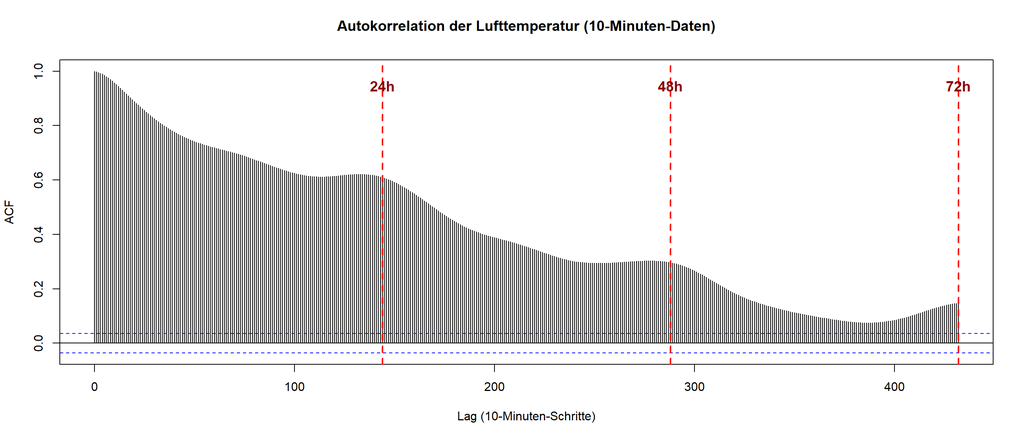

## Interpretation: Tagesverlauf in den Daten

→ Um **langfristige Trends** zu erkennen, müssen wir diesen **Tagesverlauf herausrechnen**!

## Periodische Komponente (Tagesverlauf) rausrechnen

Um langfristigere Trends in der Temperatur besser zu erkennen, können wir die Temperaturschwankungen durch den Tagesverlauf herausrechnen.

**Idee:** Der Tagesverlauf ist **periodisch** – wir können ihn als **Sinusfunktion** modellieren und optimieren!

$$T(t) = T_0 + A \cdot \sin\left(\frac{2\pi \cdot t}{P} + \phi\right)$$

wobei $T_0$ = Basispegel, $A$ = Amplitude, $P$ = Periode (1440 min = 24h), $\phi$ = Phasenverschiebung, $t$ = Zeit

```
Formula: temp_num ~ T0 + A * sin(2 * pi * t_min/P + phi)

Parameters:
     Estimate Std. Error t value Pr(>|t|)
T0  5.364e+00  5.926e-02   90.52   <2e-16 ***
A   1.044e+00  8.379e-02   12.46   <2e-16 ***
P   1.458e+03  3.191e+00  456.95   <2e-16 ***
phi 1.667e+00  1.604e-01   10.39   <2e-16 ***
---
Signif. codes:  0 '***' 0.001 '**' 0.01 '*' 0.05 '.' 0.1 ' ' 1

Residual standard error: 3.217 on 2945 degrees of freedom

Number of iterations to convergence: 14
Achieved convergence tolerance: 5.471e-06
```

## Vergleich: Modell vs. Rohdaten und bereinigte Daten

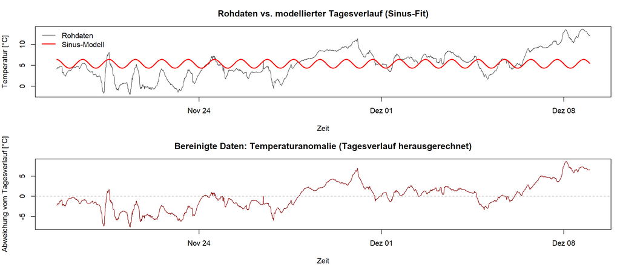

## Autokorrelation: Rohdaten vs. bereinigte Daten

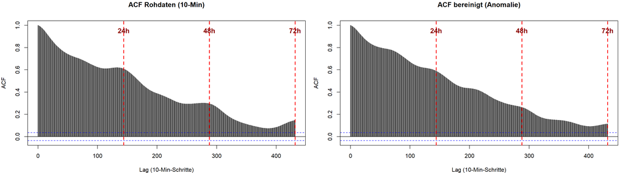

## Zusammenfassung: Tagesverlauf und Trends

### Was haben wir gemacht?

**Problem:** Tägliche Temperaturzyklen überdecken längerfristige Trends

**Lösung:** Tagesverlauf als Sinusfunktion modelliert und herausgerechnet

**Ergebnis:** Bereinigte Daten zeigen Abweichungen vom typischen Muster

### Warum ist das wichtig?

- **Autokorrelation:** Temperatur wiederholt sich alle 24h (Sonnenzyklus)
- **Bereinigung:** Entfernt Wiederholungen, macht langfristige Muster sichtbar
- **Praktisch:** Erkennung ungewöhnlicher Tage unabhängig von der Tageszeit

**Kurz gesagt:** Wir filtern das „Normale” heraus, um das „Besondere” zu sehen.

# Viele Dank für eure Aufmerksamkeit